# Understanding Society

**Introduction**

First we look at the sampling design and design weights, next population estimates are computed, and finally the effect of non-response on the estimates is investigated, as well as possible sources of non-response error.

The data:

```r
require(survey)
require(sampling)
society <- readRDS("Understanding Society innovation pnel wave A.RDS")
society$a_dvage <- as.numeric(society$a_dvage)
head(society)
```

|  | a_hidp | a_pno | pidp | a_sex | a_ioutcome | a_ageest | a_ageif | a_dvage | a_marstat | a_livesp | a_livewith | a_employ | a_reasref | a_iproxy | a_hgbiom | a_hgbiof | a_hgpart | a_hgpartner | a_adresp15 | a_adresp17 | a_ch12resp01 | a_ch12resp02 | a_ch12resp03 | a_ch12resp04 | a_ch12resp05 | a_ch12resp06 | a_ch12resp07 | a_ch12resp08 | a_ch12resp09 | … |
| --- | --- | --- | --- | --- | --- | --- | --- | --- | --- | --- | --- | --- | --- | --- | --- | --- | --- | --- | --- | --- | --- | --- | --- | --- | --- | --- | --- | --- | --- | --- |
| 1 | 1700000683 | 1 | 1700000687 | female | Fully productive interview | inapplicable | inapplicable | 64 | single and never married or never in a legally recognised ci | inapplicable | yes | yes | inapplicable | inapplicable | 0 | 0 | spouse/civil partner not in HH | 2 | -8 | inapplicable | inapplicable | inapplicable | inapplicable | inapplicable | inapplicable | inapplicable | inapplicable | inapplicable | inapplicable | … |
| 2 | 1700000683 | 2 | 1700000691 | male | Fully productive interview | inapplicable | inapplicable | 65 | divorced | inapplicable | yes | yes | inapplicable | inapplicable | 0 | 0 | spouse/civil partner not in HH | 1 | -8 | inapplicable | inapplicable | inapplicable | inapplicable | inapplicable | inapplicable | inapplicable | inapplicable | inapplicable | inapplicable | … |
| 3 | 1700000683 | 3 | 1700000695 | female | Fully productive interview | inapplicable | inapplicable | 38 | single and never married or never in a legally recognised ci | inapplicable | no | yes | inapplicable | inapplicable | 1 | 2 | spouse/civil partner not in HH | husband/wife/civil/cohabiting partner not in HH | -8 | inapplicable | inapplicable | inapplicable | inapplicable | inapplicable | inapplicable | inapplicable | inapplicable | inapplicable | inapplicable | … |
| 4 | 1700001363 | 1 | 1700001367 | female | Fully productive interview | inapplicable | inapplicable | 74 | divorced | inapplicable | inapplicable | no | inapplicable | inapplicable | 0 | 0 | spouse/civil partner not in HH | husband/wife/civil/cohabiting partner not in HH | -8 | inapplicable | inapplicable | inapplicable | inapplicable | inapplicable | inapplicable | inapplicable | inapplicable | inapplicable | inapplicable | … |
| 5 | 1700002043 | 1 | 1700002047 | female | Fully productive interview | inapplicable | inapplicable | 49 | married | yes | inapplicable | yes | inapplicable | inapplicable | 0 | 0 | 2 | 2 | -8 | inapplicable | inapplicable | inapplicable | inapplicable | inapplicable | inapplicable | inapplicable | inapplicable | inapplicable | inapplicable | … |
| 6 | 1700002043 | 2 | 1700002051 | male | Fully productive interview | inapplicable | inapplicable | 60 | married | yes | inapplicable | yes | inapplicable | inapplicable | 0 | 0 | 1 | 1 | -8 | inapplicable | inapplicable | inapplicable | inapplicable | inapplicable | inapplicable | inapplicable | inapplicable | inapplicable | inapplicable | … |

**Sampling Design**

“Include descriptions of your frame and target and population, intended sample size, and method of sample selection. Discuss potential non-sampling, sampling, and non-response errors” (Assignment 6, fox, 2018).

**Design Weights**

```r
Var. <- var(society$a_psnenip_xd) #compute variance in the design weight variable
Descr. <- cbind(t(summary(society$a_psnenip_xd)), Var.) #combine with other descriptive statistics
round(Descr., 2) #print with only two decimals
```

[output not shown]

The low variance is due to rescaling of the weights, as explained in the IP User Guide (p. 56): “Each set of weights has been scaled by a constant factor to produce a mean of one amongst cases eligible to receive the weight”. That is, the design weights are standardized on one. Rescaling, truncating, or smoothing of weights are techniques to inhibit the effect of a single observation on population estimates and its variance. Trimming may yield biased estimates, but is shown to decrease the mean square error (MSE; Lohr, 2010).

*3. Apart from the design weight, an enumerated design weight “a_psnenip_xw” is also included. Please show using syntax in R how you can calculate this weight.*

The weight a_psnenip_xw was calculated using the design weights (a_psnenip_xd), sex, age and government region. It is known that age was split up in seven groups and the government regions were split up in four, but which ones these were is unknown. To find out, we will start with a linear regression.

```r
# First, make the dataset smaller by removing unnecessary columns
society_3 <- society[,-c(5:7,9:56,60:75,77:89)]

# Investigate levels of government office region variable
levels(society_3$a_gor_dv)
nrow(society_3[society_3$a_gor_dv == "missing",])
nrow(society_3[society_3$a_gor_dv == "northern ireland",])
# None of the value are missing or northern ireland, so those can be ignored

# Create dummy variables for government office regions
society_3$NE <- society_3$a_gor_dv == "north east"
society_3$NW <- society_3$a_gor_dv == "north west"
society_3$Y <- society_3$a_gor_dv == "yorkshire and the humber"
society_3$EM <- society_3$a_gor_dv == "east midlands"
society_3$WM <- society_3$a_gor_dv == "west midlands"
society_3$EOE <- society_3$a_gor_dv == "east of england"
society_3$L <- society_3$a_gor_dv == "london"
society_3$SE <- society_3$a_gor_dv == "south east"
society_3$SW <- society_3$a_gor_dv == "south west"
society_3$W <- society_3$a_gor_dv == "wales"
society_3$S <- society_3$a_gor_dv == "scotland"

# Run linear regression (Scotland is the baseline for government office region)
coeff <- with(society_3, lm(a_psnenip_xw ~ a_psnenip_xd + a_sex + a_dvage + NE + NW + Y
                            + EM + WM + EOE + L + SE + SW + W))

# Get and sort coefficients
coeff <- coeff$coefficients
coeff.gor <- sort(coeff[5:15])

# Plot coefficients
plot(coeff.gor)

# Show coefficients
coeff.gor
```

[output not shown]

It is not completely clear which values should be grouped together, despite how nicely the weights are grouped. As can be seen on the map below, where the regions are numbered from the lowest to the highest weight, the grouping is rather strange.

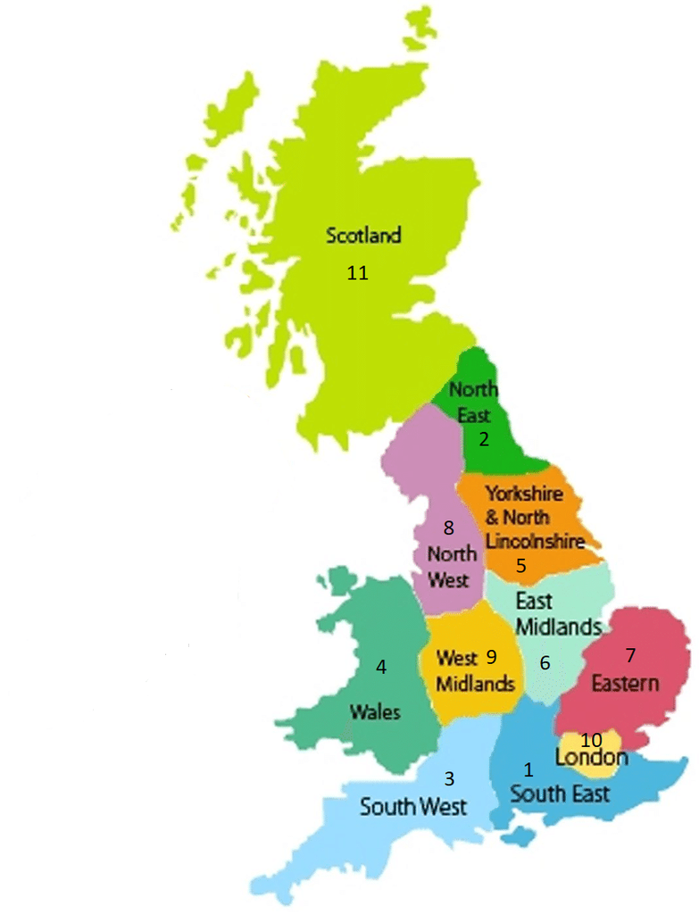

The baseline and the other two areas with a weight close to zero are Scotland, London and the West Midlands. Scotland and London are likely candidates to be categories of their own, as Scotland has a strong regional identity and London is the capital of the country. From a data-driven perspective, combining the West Midlands with any region other than London or Scotland does not make sense, as the weight difference between those region and all other regions is relatively big. From a theory-driven perspective, we cannot think of any good reason to combine the West Midlands with London or Scotland: it is not filled with cities nor is it close enough to Scotland to assume a similar population.

When assuming that the regions with a near-identical weight are in the same group and Scotland and London are two seperate categories, only a few possible groupings remain:

1. South East, South West, and North East England are the third category, with Wales and the rest of England being the last category.
- This makes some sense theoretically: the three are the very north and south of England, with the remainder being in the middle. Weight-wise however, combining the West Midlands with the areas with far lower weights does not make sense.
2. The same as above, but with the West Midlands grouped with London.
- This is more logical weight-wise than the first option, but from a theoretical perspective it is strange to combine the city with a rural area.
3. The North West, West Midlands and East of England are the third category, with Wales and the rest of England being the last category.
- Weight-wise it is just as logical or illogical as the first option, but from a theoretical standpoint taking three areas in the middle seems to have less of a basis than taking the outer areas like is done in the first option.
4. The West Midlands alone being the third category, with the rest of England being the fourth.
- This fits weight-wise, but why the West Midlands should be taken seperately is a mystery. It is however less absurd than combining it with London: the West Midlands may have unique features that we do not know about, but we do know that it is not a capital like London.

In conclusion, the fourth option seems the most likely, as the grouping is logical from a data-driven perspective and while it does not quite make sense theoretically, there is no evidence that it is incorrect. The best alternative is the first option, as it makes the most sense from a theoretical perspective.

The next step is to decide the age groups

```r
# Gather grouped region in one dummy variable
# This is done by creating a dummy variable that is true when London, Scotland and the
# Western Midlands are not.
society_3$grouped_gor <- with(society_3, L!=T & S!=T & WM!=T)
# Change age into factor
society_3$age_fac <- as.factor(society_3$a_dvage)
# It's ordinal, so there is no need to create dummy variables

# Rerun linear regression
coeff2 <- with(society_3, lm(a_psnenip_xw ~ a_psnenip_xd + a_sex + WM + L
                             + grouped_gor + age_fac))

# Get coefficients
coeff2 <- coeff2$coefficients
coeff2.age <- coeff2[7:102]

# Change names of coefficients into numbers
test <- unlist(strsplit(names(coeff2.age), "age_fac"))
names(coeff2.age) <- test[test!=""]

# Plot coefficients
plot(as.numeric(names(coeff2.age)), coeff2.age)
for (i in seq(0,110,10)+0.5){
 abline(v=i, col="red")
}
```

[output not shown]

Considering these results, the most logical categories are 0-20, 21-30, 31-40, 41-50, 51-70, 71-80, 81+. Theoretically speaking, the 51-70 category is a bit strange, but due to the rather convincing difference in weights between the 71-80 group and the neighbouring groups, two of the categories between 21 and 70 must be joined, and 51-70 is the most uniform weight-wise.

```r
# Assign the levels
levels(society_3$age_fac) <- c(rep("group0_20", 15), rep("group21_30", 10),
                               rep("group31_40", 10), rep("group41_50",10),
                               rep("group51_70", 20), rep("group71_80", 10),
                               rep("group_80", 22))


# Create non-dummy variable for government office groups
society_3$gor_groups <- "England_Wales"
society_3$gor_groups[society_3$L == T] <- "London"
society_3$gor_groups[society_3$S == T] <- "Scotland"
society_3$gor_groups[society_3$WM == T] <- "West Midlands"

# Create table
with(society_3, table(age_fac,gor_groups))
# None of the groups has zero observations

# Run linear regression again
coeff3 <- with(society_3, lm(a_psnenip_xw ~ a_psnenip_xd + a_sex + gor_groups + age_fac))

#Get coefficients
coeff3 <- coeff3$coefficients
coeff3
```

[output not shown]

The regression analysis reveals which groups were under- and overrepresented in the sample (compared to the population of Great Britain), with higher weights being assigned to underrepresented groups. While the weights are mostly decided by the design weights, the post-stratification does alter them.

**Population Estimates** *4. What is the proportion of employed people of working age (15-64) in the population?*

```r
# First, we investigate the a_employ variable.
levels(society$a_employ[society$a_dvage > 15 & society$a_dvage < 64])
# The variable a_employ has seven levels.
summary(society$a_dvage[society$a_employ=="yes"])
summary(society$a_dvage[society$a_employ=="no"])
# Yes and no contain people of over 21 years of age.
society[society$a_employ=="missing",]
# Missing does not appear in the data
society[society$a_employ=="inapplicable",]
# Inapplicable seems to contain all children and youths of 21 years and younger
# It cannot be assumed that none of them is employed. It can however be assumed that only a
# small part of them is employed, as children under 15 cannot legally work.
society[society$a_employ=="proxy respondent",]
# No rows returned
society[society$a_employ=="refuse",]
society[society$a_employ=="don\'t know",]
# Both refuse and don't know contain one row. These can be treated as missing data.

# Thus, our goal is to compare the proportion of employed people (yes) of working age against
# the number of unemployed people (no, inapplicable), excluding the missing data (refuse, don't know)

with(society, society[a_employ=="yes" & a_dvage >64,])
# There are people older than 64 still working, we should take those out.
with(society, society[a_employ=="yes" & a_dvage <15,])
# No one younger than 15 years is reported to be working, which is to be expected as it was not
# a question asked to people under 21 years of age.

# Since we wish to know the proportion of employed people of working age, we need 2 groups, one with employed adults and one with unemployed adults and employed elderly.
society$employ_dv <- as.numeric(0)
society$employ_dv[society$a_employ=='yes' & society$a_dvage <= 65] <- 1

# Now we can calculate the proportion
# Create design
# Don't remove the missing values yet, as the weights are calculated including missing values
Design <- svydesign(ids=~a_hidp, strata=~a_strata, data=society, weights=~a_psnenip_xw)
# Make a subset of non-missing values
Nonmiss <- with(Design, subset(Design, a_employ!="refuse" & a_employ!="don\'t know"))
svymean(~employ_dv, Nonmiss)
confint(svymean(~employ_dv, Nonmiss))
# 43,3% of the population is employed, with a 95% confidence interval of 41.4%-45.2%
```

[output not shown]

*5. Please investigate the relationship between age and household composition for the population of Great Britain.*

*a. Investigate which age variable you should use.* There are four variables in the data expressing the age of respondents: a_agegr5_dv, a_agegr10_dv, a_agegr13_dv, a_dvage. The first three are categorical varibles, divided into groups as seen in the UK Labour Force Survey. The fourth variable, a_dvage, denotes the age of respondents in completed years at the moment the interview took place. This was computed by comparing the date of birth and the interview date, or using an estimate (see estimated age variable a_ageest (n = 22), and imputated age variable a_ageif (n = 55)).

The first categorical variable, a_agegr5_dv, contains 15 categories indicating age in five-year partitions up to ‘70 years or older’. The variable a_agegr10_dv is highly similar, indicating age in ten-year intervals, and consisting of 8 different categories between ages zero and seventy-plus. Finally, a_agegr13_dv consists 13 levels, with unequal age intervals under the age of 20 (namely 0-15, 16-17, and 18-19 years old), five-year intervals between the ages 20 and 64, and a sigle interval containing all ages from 65 years old upward.

To investigate the relationship between age and household composition, it is necessary to know which households consist of children living at home, and which don’t. Presumably, the largest variation between children living at home and those living independently occurs within the age group 15-25 year-olds. If we would use the ten-year intervals to indicate age, we might get less precise estimates, because of the large variance wihtin the age category ‘10-19 years old’. Therefore, we decided to use an age variable with smaller intervals. Because of the unequal intervals in the age variable with 13 categories, it should be analysed as ordinal variable. To interpret the relationship with household composition, this is not ideal. Ultimately, we decided to use either a_dvage or a_agegr5_dv.

*b. Construct a new variable “household_composition” from the following four variables: “a_livesp_dv, a_cohab_dv, a_single_dv, a_mastat_dv”.* Eurostat distinghuishes three types of variables used to descripte household composition: - Household size; - Number of children; - Household type, with levels: couple (with/without children), single adult (with/without children), other type of household (with/without children); )

First, create variable household size: Compute variable household size, number of children per household, household type

```r
levels(society$a_livesp_dv)
levels(society$a_cohab_dv)
levels(society$a_single_dv)
levels(society$a_mastat_dv)

##### HOUSEHOLD SIZE PER HOUSEHOLD
# a_hidp - Household identifier
# Household size: count for each household, how many persons there are in.
count <- as.matrix(table(society$a_hidp)) # number of occurrences of each a_hidp (indicator of size of household)
summary(count)
households <- rownames(count)

# create variable to assign household size to each individual person
society$household_size <- NA
for (i in households) { # for each household..
  society$household_size[society$a_hidp == i] <- count[i,] # maybe this can be written into nicer R code.
households <- rownames(count) # all household ID's
}
# create 'household_info' to store all the information concerning households
# columns: household_size, number of children, children yes/no,
household_info <- matrix(NA, length(households), 5)
rownames(household_info) <- households
colnames(household_info) <-
  c("household_size",
    "kidsperHousehold",
    "hasKids",
    "hasCouple",
    "household_composition"
  )

household_info[, "household_size"] <- count

##### HOUSEHOLD SIZE PER PERSON
society$household_size <- NA
for (i in households) {
  # for each household..
  society$household_size[society$a_hidp == i] <-count[i, ] # assign household size to each individual person
}

##### NUMBER OF CHILDREN PER HOUSEHOLD
countKids <-
  function(household) {
    # function that counts kids for a given household ID
    count <-
      as.numeric(table(society$a_mastat_dv[society$a_hidp == household])["Child under 16"])
    count
  }

kidsperHousehold <- matrix(NA, length(households), 1) # empty vector to store number of kids per household
for (i in 1:length(households)) {
  kidsperHousehold[i,1] <- countKids(households[i]) # store kids per household
}
household_info[, "kidsperHousehold"] <- kidsperHousehold

##### HOUSEHOLD TYPE
#### children yes or no
# hasKids <- matrix(NA, length(households), 1)
# hasKids <- kidsperHousehold > 0 # logical to indicate whether household has children T/F

##### HOUSEHOLD TYPE
#### children yes or no
household_info[, "hasKids"] <- kidsperHousehold > 0 # to indicate whether household has children 0/1
society$singleadults <- society$a_single_dv == "Yes"

#### COUPLE YES/NO
society$inacouple <- society$a_livesp_dv == "Yes" | society$a_cohab_dv == "Yes" # true for all couples
#hasCouple <- any(society$inacouple[society$a_hidp == households[50]])
for (i in 1:1489) {
  household_info[i, "hasCouple"] <- any(society$inacouple[society$a_hidp == households[i]])
}
#### SINGLE YES/NO, OTHER..
society$single <- society$a_single_dv == "Yes" # true for all singles
#hasCouple <- any(society$inacouple[society$a_hidp == households[50]])
for (i in 1:1489) {
  household_info[i, "hasCouple"] <- any(society$inacouple[society$a_hidp == households[i]])
}

# calculate number of children per household
#############################
cwc <- matrix(NA, 1489, 1) # indicator for couples with children
cwoc <- matrix(NA, 1489, 1) # indicator for couples without children
swc <- matrix(NA, 1489, 1) # indicator for single adults with children
swoc <-matrix(NA, 1489, 1) # indicator for single adults without children
owc <- matrix(NA, 1489, 1) # indicator for other with children
owoc <- matrix(NA, 1489, 1) # indicator for other withouth children

for (i in 1:1489) {
  cwc[i, ] <- # hasCouple = 1 and hasKids = 1
    household_info[i, "hasCouple"] == 1 &&
    household_info[i, "hasKids"] == 1
  cwoc[i, ] <- # hasCouple = 1, hasKids = 0
    household_info[i, "hasCouple"] == 1 &&
    household_info[i, "hasKids"] == 0
  swc[i, ] <- # if haskids is true and householdsize - kidsperHousehold = 1: single household with kids
    household_info[i, "hasKids"] == 1 &&
    as.numeric(household_info[i, "household_size"]) - as.numeric(household_info[i, "kidsperHousehold"]) == 1
  swoc[i, ] <- # if household size = 1 single without children.
    household_info[i, "household_size"] == 1
}

# householdgrouper <- society$a_hidp == i # logical indicator that groups households together
# society$a_pno[householdgrouper] #
household_info[cwc, "household_composition"] <- "Couple with children" # Couples with children
household_info[cwoc, "household_composition"] <- "Couple without children" # Couples without children
household_info[swc, "household_composition"] <- "Single with children" # Single with kids
household_info[swoc, "household_composition"] <-"Single without children" # Singles without kids

for (i in 1:1489) { # create 'other'
  owc[i, ] <- # if for the rest: hasKids = 1: other with kids
    is.na(household_info[i, "household_composition"]) &&
    household_info[i, "hasKids"] == 1
  owoc[i, ] <- # for the rest: hasKids = 0: other without kids.
    is.na(household_info[i, "household_composition"]) &&
    household_info[i, "hasKids"] == 0
}

household_info[owc, "household_composition"] <- "Other with children" # Couples without children
household_info[owoc, "household_composition"] <- "Other without children" # Couples without children

## turn it into factor variable household_type.
household_type <- household_info[, "household_composition"]

household_type <- factor(household_type,
  labels = c(
    "Couple with children",
    "Couple without children",
    "Single adult with children",
    "Single adult without children",
    "Other with children",
    "Other without children"
  )
)

# count of children
table(household_type) # show how many of each category there are.

# with /by a_hidp, table the a_mastat_dcv
# number of children (according to eurostat properties..)
##################################################################
```

*source* https://ec.europa.eu/eurostat/statistics-explained/index.php/Household_composition_statistics

*c.Which weight should you use here?* For this analysis, we want to use a weight per person (PSN), as it is impossible to calculate age per household. We also want to use the enumeration grid weights (EN), as both age and household composition have no missing values. We want the weights of the first wave (IP), as that is the one we are investigating. Finally, we want to use the stratified weights (XW) rather than the design weights, as we are investigating population values and not sample values. Thus, we want to use the weight a_psnenip_xw, as this is the only weight that covers the correct data in the correct way.

**Non-response**

*6. Not all sample members you included in questions 1-5 participated in the survey. Use the variable “a_ivfio” to investigate how many people personally conducted an interview.*

Of the 3600 individuals in the sample, there are 459 children under the age of ten. These sample members are enumerated individuals, but ineligible for an interview. Therefore, the number of eligible individuals in the sample is 3141. Of these 3141 eligible individuals, only 2656 respondents personally completed an interview. This number consists of 2399 adults who performed a full interview, and 257 interviews with children. Taken together there are 485 cases of (partial) unit nonrespons within the subset of eligible individuals.

Moreover, there are 169 sample members for whom a proxy interview was conducted with a close relative or cohabitant (generally a spouse, partner or adult child; Understanding Society, ‘Questions about variables’, N.D.). Questions answered on the nonresponders’ behalf were used to estimate factual information about the nonrespondent. Information about their beliefs is not collected by proxy, and are therefore indicated as missing (item nonrespons).

Because (partial) nonrespons can lead to nonresponse bias, it is important to investigate the effect of nonresponse on the estimates generated above. Ideally, we would both compare respondents to partial nonresponse, and unit nonresponse. Because of time constraints within this research project, we only investigate unit nonresponse.

```r
summary(society$a_ivfio) #what's in the variable?
adults <- sum(society$a_ivfio == "Full interview") #the full interviews with adults
youths <- sum(society$a_ivfio ==  "Youth Interview") #the interviews with children
sum(adults, youths) #all personally completed interviews

NR <- matrix(0, 3600, 1) #create nonresponse indicator
society <- cbind(society, NR) #add to dataframe
#the nonresponse indicator is 1 for all (partial) unit nonresponse
society$NR[which(society$a_ivfio == "Youth: Oth non-int")] <- 1
society$NR[which(society$a_ivfio == "Proxy interview")] <- 1
society$NR[which(society$a_ivfio == "Refusal")] <- 1
society$NR[which(society$a_ivfio == "Other non-intvw")] <- 1
society$NR[which(society$a_ivfio == "Language difficulties")] <- 1
society$NR[which(society$a_ivfio == "Too infirm/elderly")] <- 1
society$NR[which(society$a_ivfio == "Ill/away during survey period")] <- 1
```

[output not shown]

*7. Repeat your analysis under question 4. Use only the people who personally did an interview. What is your conclusion? Is there a difference between respondents and nonrespondents when it comes to their employment?*

```r
levels(society$a_ivfio)
```

[output not shown]

There are forty levels, but by looking at the site (https://www.understandingsociety.ac.uk/documentation/innovation-panel/dataset-documentation/wave/1/datafile/a_indall_ip/variable/a_ivfio), we find only 10 appear in the first wave. Of those, only full interview and youth interview indicate interviews that personally did an interview. Language difficulties is a rather neutral description, but looking at the variable i_proxy:

```r
society$a_iproxy[society$a_ivfio=="Language difficulties"]
```

[output not shown]

Shows that language difficulty also indicates missing data. Thus, only two of the levels indicate a personal interview and thus should be included for this analysis.

```r
I_personal <- with(Nonmiss, subset(Design, a_ivfio=="Full interview" | a_ivfio=="Youth Interview"))
svymean(~employ_dv, I_personal)
confint(svymean(~employ_dv, I_personal))
```

[output not shown]

*8. Using only variables from this dataset, can you find variables which could potentially be useful for constructing nonresponse weights? Why these variables?* There are several types of nonrepsonse (unit nonresponse, household nonresponse, item nonresponse, and attrition). We’re going to look into auxiliary variables that can be useful for constructing weights for unit nonresponse.

Nonresponse can seriously threat the quality of estimates if the nonresponders differ from the responders in the study. We can adjust for this by the use of auxiliary variables that hold information about the entire sample. We can compare the distribution of the auxiliary variables of the population with its response distribution, and assess whether the response is representative for the whole population.

If the distributions differ, we must conclude that nonresponse has lead to a nonrepresentative sample. We can adjust for this by constructing nonresponse weights from the auxiliary variables. Then the weighted sample is representative with respect to the auxiliary variables used. Different choices of auxiliary variables lead to different weights. In order to the weights to be useful, it is important to use powerful auxiliary variables (Brick, 2013).

The IP User Guide states that “all models used to predict response propensities as described in the Technical Details are fitted using stepwise backward logistic regression with p=0.05” (p. 56). Compared to other selection strategies, this is a fairly simple one. Considering these other strategies for selecting auxiliary variables for weighting adjustments for nonresponse, we advise to look into Schouten’s (2007) proposed strategy of a forward inclusion-backward elimination algorithm and/or S??rndal and Lundstr??m’s (2010) paper.

We opt for a stepwise backwards logistic regression of because this method is similiar to, yet easier to apply than the selection strategies described in Schouten (2007) S??rndal and Lundstr??m’s (2010). Most important, this selection strategy was also used in constructing the original weights in the dataset. With this method, we hope to identify variables that predict non-response.

First, we need to divide the population in the respondents and nonrespondents There are two stages of nonresponse we want to consider: * person nonresponse: whether a personal interview was conducted yes or no * household nonresponse: defined as completian of at least the household grid

```r
society$NR # non response indicator (see Q6)
```

[output not shown]

```r
mean(society$NR) # compute proportion nonresponders
```

```
[1] 0.2622222
```

```r
levels(society$a_hhresp_dv) # looks like all households at least filled in the grid, so we only look into person (unit) nonresponse.
```

```
[1] "All present adults interviewed"        "All present adults interview or proxy" "At least one adult interview"
[4] "No adult interviews"
```

It looks like household nonresponse cannot be identified in this dataset. The levels of variable A_hhresp_dv suggests that all households at least completed the household grid. Even though according to the user guide, the household response should be about 59%. For now, we only take into account individual nonresponse. If available it could also be interesting to use household nonresponse as a potentially useful auxiliary variable.

Second, we need to identify the variables we want to put into our stewpise logistic regression. Logically, we would use all variables in our dataset but before we do that we need to check the assumptions of logistic regression:

1. DV on dichotomous scale
2. IV(s) should be on continuous or categorical scale
3. Independence of observations + the dependent variable should have mutually exclusive and exhaustive categories.
4. Linear relationship between any continuous independent variables and the logit transformation of the dependent variable.

We know that assumptions 1-3 hold. We can check assumption 4 with the Box’s M test. Some other issues we have to deal with: - Some of the possible predictors have complete separation for the non-response variable. We will exclude these variables from the model, because they can render unstable regression estimates with very large standard deviations. - Multicollinearity between IVs. We think multicollinearity of IVs (for example the different age variables) shouldn’t be a problem, since it isn’t a strict assumption for logistic regression.

The method of stepwise logistic regression allows us to look into interactions between auxiliary variables, but in practice this is almost never used (Bick, 2013). However, we do think it is interesting to look into, but because it will make our analysis much more complicated and more difficult to interpret, so for this assignment we will not look into it.

Third, we apply selection strategy:

```r
halffullmodel <- glm(NR ~
  a_gor_dv + a_urban_dv + a_sex + a_racel_dv +
  a_employ + a_dvage + a_agegr5_dv + a_agegr10_dv + a_agegr13_dv +
  hh_size + single_adult + inacouple + single
  ,family = binomial, data = society)
```

[output not shown]

Create some tables showing response rates for different categories for the selected variables:

```r
table(society$person_response)
table(society$person_response, )
table(as.matrix(society$person_response), as.matrix(society$a_sex), dnn = c("response", "sex"))
```

[output not shown]

**References** Kumar, Rohit. (2014). Respondent Selection Methods in Household Surveys. Jharkhand Jounral of Development and Management Studies. XII. 5701-5708. Lohr, S. (2010). Sampling: Design and Analysis (second edition). Brooks/Cole, Boston, USA. Sa??rndal, C.E. and Lunsdstr??m, S. (2010). Design for Estimation: Identifying Auxiliary vectors to reduce nonresponse bias. Survey Methodology, 36, 131???144. Schouten, B. (2007). A Selection Strategy for Weighting Variables Under a Not-Missing- at-Random Assumption. Journal of Official Statistics, 23, 51???68.